# Project course 2

One of our learners ;)

```
           (               )   (        )                    )
   (       )\ )  *   )  ( /(   )\ )  ( /(     (       (   ( /(           *   )
   )\     (()/(` )  /(  )\()) (()/(  )\())    )\    ( )\  )\())     (  ` )  /(
((((_)(    /(_))( )(_))((_)\   /(_))((_)\  ((((_)(  )((_)((_)\      )\  ( )(_))
 )\ _ )\  (_)) (_(_())   ((_) (_)) __ ((_)  )\ _ )\((_)_   ((_)  _ ((_)(_(_())
 (_)_\(_) / __||_   _|  / _ \ | _ \\ \ / /  (_)_\(_)| _ ) / _ \ | | | ||_   _|
  / _ \   \__ \  | |   | (_) ||   / \ V /    / _ \  | _ \| (_) || |_| |  | |
 /_/ \_\  |___/  |_|    \___/ |_|_\  |_|    /_/ \_\ |___/ \___/  \___/   |_|

                )   (                      )     )        (
             ( /(   )\ )   (     (      ( /(  ( /(        )\ )
      (   (  )\()) (()/(   )\    )\     )\()) )\())  (   (()/(
      )\  )\((_)\   /(_))(((_)((((_)(  ((_)\ ((_)\   )\   /(_))
     ((_)((_) ((_) (_))  )\___ )\ _ )\  _((_)  ((_) ((_) (_))
     \ \ / / / _ \ | |  ((/ __|(_)_\(_)| \| | / _ \ | __|/ __|
      \ V / | (_) || |__ | (__  / _ \  | .` || (_) || _| \__ \
       \_/   \___/ |____| \___|/_/ \_\ |_|\_| \___/ |___||___/
```

Yep, you are probably right. Last time I thought about volcanoes goes a long way back. Probably primary school, most likely in some kind of art class.. can almost smell the drying gouache paint.

When I think of volcanoes, I picture a nice mountain cone with flames coming out at the top and lava running down its side, like chocolate running down the ice-cream on a hot summer days. Missing ice cream these days…

In Switzerland we don’t often come across volcanoes… We do we need to go abroad, but where? We will start by plotting a map of where to find volcanoes… and, if we are lucky, we will end our tour by witnessing a live eruption!

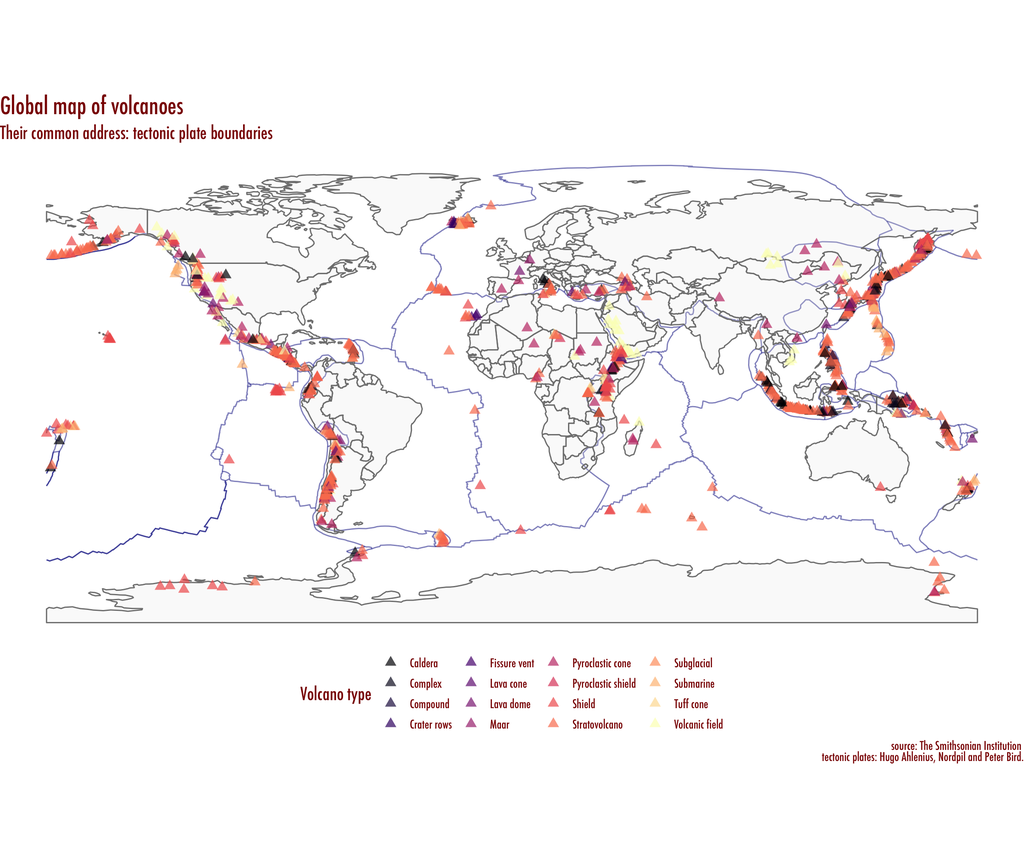

```r
# data for world map 1
 ggplot()+
   geom_sf(data=boundaries, colour="darkblue",alpha=0.5)+
   geom_sf(data=world,colour="grey50", alpha=0.2)+
   geom_point(data=data_world_map, aes(x=longitude, y=latitude, color=primary_volcano_type),shape=17, size=3, alpha=0.7)+
   scale_color_viridis_d(option="magma")+

   labs(
     title="Global map of volcanoes",
     subtitle= "Their common address: tectonic plate boundaries",
     caption="source: The Smithsonian Institution <br>tectonic plates: Hugo Ahlenius, Nordpil and Peter Bird.",
     x="",
     y="",
     color="Volcano type"
   )+
   theme_void() +
   theme(
     plot.title = element_markdown(colour="#8b0000",
                                   family = "Futura Condensed Medium",
                                   size = 20),
     plot.subtitle =  element_markdown(colour="#8b0000",
                                      family = "Futura Condensed Medium",
                                      size = 15),
     plot.caption=  element_markdown(colour="#8b0000",
                                       family = "Futura Condensed Medium",
                                       size = 10),

     legend.title = element_text(colour="#8b0000",
                                      family = "Futura Condensed Medium",
                                      size = 15),
     legend.text = element_text(colour="#8b0000",
                                       family = "Futura Condensed Medium",
                                       size = 10),
     legend.position = "bottom"
   )
```

There seems to be quite a few, maybe too many. So let’ narrow our list down a little. Let’s take the last 10 year and find out which were the most active volcanoes… Where can we get more information about them? On Wikipedia of course!

```r
# data for world map 1


gt_table_data %>%
  select(volcano_name, country, number_eruptions, population_within_10_km) %>%
  gt() %>%
  tab_header(md("**Top 10 <span style='color:darkred'>volcanoes**</span>"),
             subtitle = "With the most eruptions in the last 10 years") %>%
  cols_label(
    volcano_name = md("**Volcano**"),
    country = md("**Country**"),
    number_eruptions =md("**Number of eruptions**"),
    population_within_10_km = md("**Population < 10km**")
  ) %>%

  fmt_number(
    columns = vars(population_within_10_km),
    decimals =0 ,
    use_seps = TRUE,
    sep_mark = "'",
  ) %>%
  tab_style(
    style = list(
      cell_fill(color = "darkred",
                alpha=1),
      cell_text(color = "white")
    ),
    locations = cells_body(
      columns = vars(number_eruptions),
      row=1)
  ) %>%

  tab_style(
    style = list(
      cell_fill(color = "darkred",
                alpha=1),
      cell_text(color = "white")
    ),
    locations = cells_body(
      columns = vars(population_within_10_km),
      row=7)
  ) %>%
  fmt_missing(
    columns = 4,
    missing_text = "-"
  ) %>%
    fmt_markdown(
      columns=vars(volcano_name)

    )
```

**Top 10 volcanoes**

With the most eruptions in the last 10 years

| **Volcano** | **Country** | **Number of eruptions** | **Population < 10km** |
| --- | --- | --- | --- |
| Fournaise, Piton de la | France | 22 | 55'859 |
| San Cristobal | Nicaragua | 21 | 7'876 |
| Ulawun | Papua New Guinea | 17 | - |
| Klyuchevskoy | Russia | 15 | 0 |
| Etna | Italy | 13 | 3'291 |
| Telica | Nicaragua | 13 | 21'990 |
| Soputan | Indonesia | 12 | 69'991 |
| Mayon | Philippines | 12 | - |
| Cleveland | USA | 12 | - |
| Karangetang | Indonesia | 11 | - |

Wow! that is quite a number of volcanic eruptions! How long do these last and how powerful are they? Let’s draw a timeline.

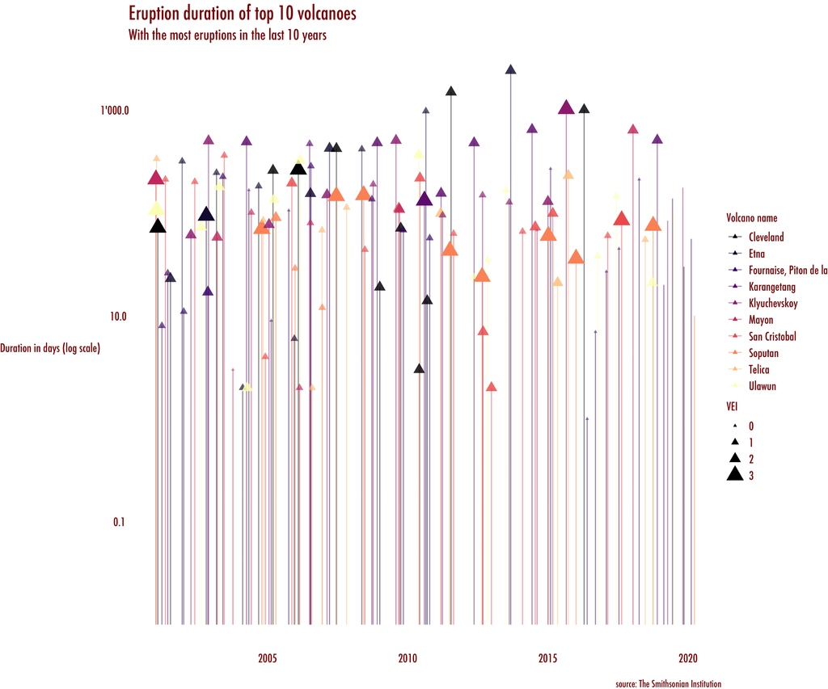

```r
# data for world map 1

duration_chart %>%
  mutate(active_days=as.numeric(active_days)) %>%
   filter(active_days>0) %>%
ggplot(aes(x = date_start,
           y = active_days,
           aes(color = volcano_name,
               fill = volcano_name)
))+
  ## curves
  ggforce::geom_link(
    aes(
      x = (date_start),
      xend = (date_start),
      y = 0.01,
      yend = active_days ,
      color = volcano_name,
     # alpha = vei
    ),
    n =360,
    size = .5,
    alpha=0.5
  )+
  geom_point(
    aes(
      #  y = active_days,
      size = vei,
      alpha=vei,
      color = volcano_name,
      fill = volcano_name
      # alpha = active_days
    ),
    shape = 17)+



scale_color_viridis_d("Volcano name",option="magma",guide = "legend")+
  scale_fill_viridis_d("Volcano name",option="magma",guide = "legend")+
  scale_alpha_continuous("",range = c(0.5, 1))+
  scale_size("VEI",range=c(1,6),
             trans="exp")+
  #scale_y_continuous(labels=function(x) format(x, big.mark = "'", scientific = FALSE))+
   scale_y_log10(labels=function(x) format(x, big.mark = "'", scientific = FALSE))+

#coord_polar(theta = "y", start = pi * 1.5, clip = "off") +
  labs(
    title="Eruption duration of top 10 volcanoes",
    subtitle= "With the most eruptions in the last 10 years",
    caption="source: The Smithsonian Institution",
    x="",
    y="Duration in days (log scale)"
  )+
  guides(alpha=FALSE)+
  theme_void() +


  theme(
    plot.background = element_blank(),
    plot.title = element_markdown(colour="#8b0000",
                                  family = "Futura Condensed Medium",
                                  size = 20),
    plot.subtitle =  element_markdown(colour="#8b0000",
                                      family = "Futura Condensed Medium",
                                      size = 15),
    plot.caption=  element_markdown(colour="#8b0000",
                                    family = "Futura Condensed Medium",
                                    size = 10),

    legend.position = "right",
    axis.text.y = element_text(size=12, face="bold", colour = "darkred",family = "Futura Condensed Medium"),
    axis.title.y = element_text(size=12, face="bold", colour = "darkred",family = "Futura Condensed Medium"),
    axis.text.x = element_text(size=12, face="bold", colour = "darkred",family = "Futura Condensed Medium"),
    axis.title.x = element_text(size=12, face="bold", colour = "darkred",family = "Futura Condensed Medium"),
    legend.text= element_text(size=12, face="bold", colour = "darkred",family = "Futura Condensed Medium"),
    legend.title= element_text(size=12, face="bold", colour = "darkred",family = "Futura Condensed Medium")

    )
```

That is a diverse set of eruptions. How different are the periods where these volcanoes are active?

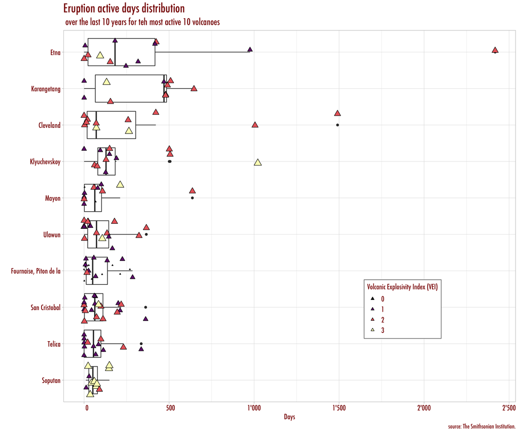

```r
# data for world map 1


eruption_days %>%
  filter(volcano_name %in% top10,
         start_year>2000) %>%
  mutate(vei=as.integer(vei)) %>%
  ggplot(aes(y=fct_reorder(volcano_name, active_days,mean),x=active_days ))+ #fill=volcano_name
  geom_boxplot()+
  geom_jitter(aes(size=vei, fill=vei,),shape=24)+
  scale_size(range=c(0.5,4))+
  scale_fill_viridis_c("Volcanic Explosivity Index (VEI)",option="magma", direction=1,guide = "legend")+

  scale_x_continuous(labels=function(x) format(x, big.mark = "'", scientific = FALSE))+
  labs(
    title="Eruption active days distribution",
    subtitle=" over the last 10 years for teh most active 10 volcanoes",
    caption="source: The Smithsonian Institution.",
    x="Days",
    y=""

  )+
   guides(size=FALSE)+

  theme_light() +
  theme(
    legend.position = c(.75, .25),
    legend.background =element_rect(
      size=0.5, linetype="solid",
      colour ="grey50"),
    axis.text.y = element_text(size=12, face="bold", colour = "darkred",family = "Futura Condensed Medium"),
    axis.text.x = element_text(size=12, face="bold", colour = "darkred",family = "Futura Condensed Medium"),
    axis.title.x = element_text(size=12, face="bold", colour = "darkred",family = "Futura Condensed Medium"),
    plot.title = element_text(size=20, face= "bold", colour= "darkred",family = "Futura Condensed Medium" ),
    plot.subtitle = element_text(size=15, face= "bold", colour= "darkred",family = "Futura Condensed Medium" ),
    plot.caption = element_text(size=10,  colour= "darkred",family = "Futura Condensed Medium" ),
    legend.text= element_text(size=12, face="bold", colour = "darkred",family = "Futura Condensed Medium"),
    legend.title= element_text(size=12, face="bold", colour = "darkred",family = "Futura Condensed Medium")
  )
```

Interesting. I think you will agree with me: I would not mind seeing of these eruptions (from a safe distance of course!). But how patient will we have to be?

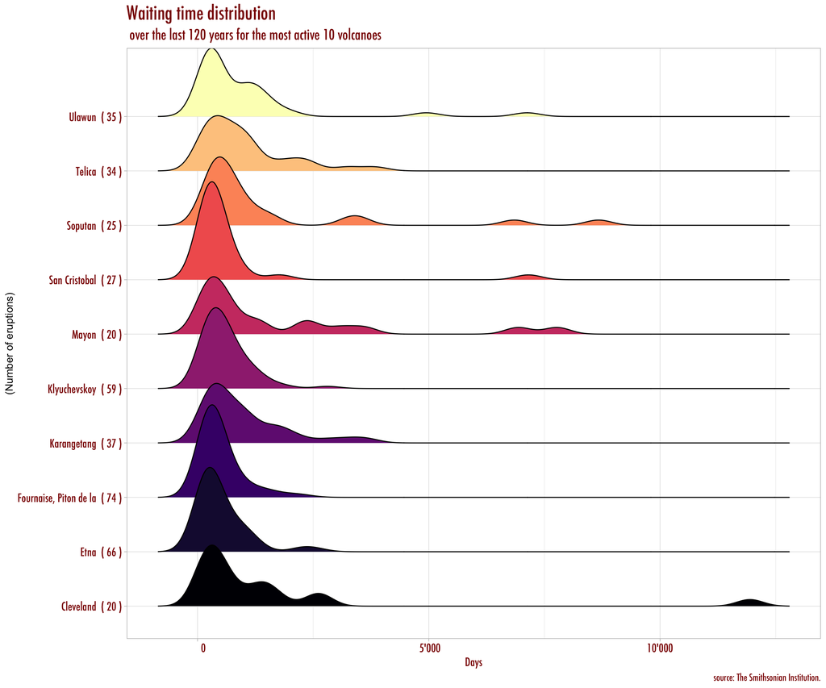

```r
# data for world map 1

eruption_days %>%
  filter(volcano_name %in% top10,
         start_year>1920) %>%
  group_by(volcano_name) %>%
  arrange(volcano_name) %>%
  arrange(date_start) %>%
  mutate(waiting=difftime(date_start,lag(date_start), units = "days"),
         number_eruptions=n() )%>%
  mutate(volcano_name=paste(volcano_name, " (",number_eruptions,")"))%>%

  ggplot(aes(y=fct_reorder(volcano_name, waiting,max),x=waiting, fill=volcano_name))+
  geom_density_ridges()+

  #geom_jitter(aes(size=vei),shape=2, colour="darkred", alpha=0.7)+
  scale_fill_viridis_d(option="magma", direction=1)+
  scale_x_continuous(labels=function(x) format(x, big.mark = "'", scientific = FALSE))+
  labs(
    title="Waiting time distribution",
    subtitle=" over the last 120 years for the most active 10 volcanoes",
    caption="source: The Smithsonian Institution.",
    x="Days",
    y="(Number of eruptions)",
    size="Volcanic Explosivity Index (VEI)"
  )+
  guides(fill=FALSE)+
  theme_light() +
  theme(
    legend.position = c(.75, .25),
    legend.background =element_rect(
      size=0.5, linetype="solid",
      colour ="grey50"),
    axis.text.y = element_text(size=12, face="bold", colour = "darkred",family = "Futura Condensed Medium"),
    axis.text.x = element_text(size=12, face="bold", colour = "darkred",family = "Futura Condensed Medium"),
    axis.title.x = element_text(size=12, face="bold", colour = "darkred",family = "Futura Condensed Medium"),
    plot.title = element_text(size=20, face= "bold", colour= "darkred",family = "Futura Condensed Medium" ),
    plot.subtitle = element_text(size=15, face= "bold", colour= "darkred",family = "Futura Condensed Medium" ),
    plot.caption = element_text(size=10,  colour= "darkred",family = "Futura Condensed Medium" ),
    legend.text= element_text(size=12, face="bold", colour = "darkred",family = "Futura Condensed Medium"),
    legend.title= element_text(size=12, face="bold", colour = "darkred",family = "Futura Condensed Medium")
  )
```

So now, sit back and relax (from a safe distance)

5…4…3…2…1

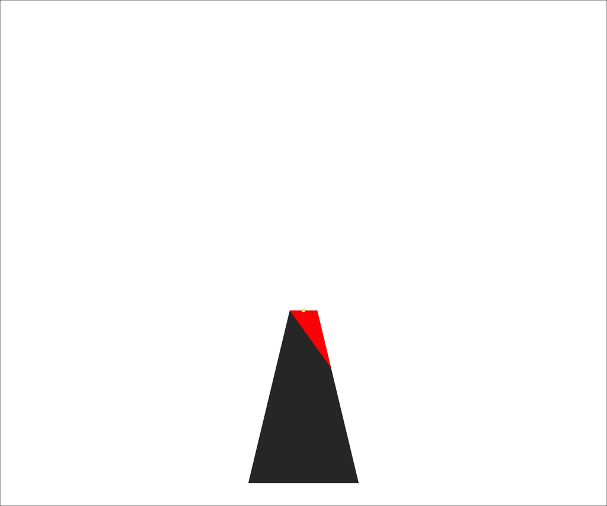

```r
volc<-data.frame(x=c(1,0.5,0.25 ,0,-0.25,-0.5,-1), y=c(0,0.5,0.75,0.75,0.75,0.5,0))


lava<-data.frame(x=c(0.5,0.25,-0.25),y=c(0.5,0.75,0.75))

cone<-data.frame(x=c(1,0.25,0,-0.25,-1), y=c(0.5,1.5,1.75,1.5,0.5))



projectile<- function(velocity, angle,steps=0.1,y_0=0.75, g=9.81){
      angle_rad<-angle*pi/180

      time_to_target<- velocity*sin(angle_rad)/g+(sqrt(velocity*sin(angle_rad)*velocity*sin(angle_rad)+2*g*y_0)/g)
      time_to_target<-round(time_to_target,digit=1)
      time_steps<-seq(0,12,steps)
      x<-velocity*cos(angle_rad)*time_steps
      y<-y_0+velocity*sin(angle_rad)*time_steps-0.5*(g*time_steps*time_steps)

       #
answer<-tibble(tt=time_steps,xt=x,yt=y)

     return(answer)
 }


shots<-tibble(n_shots=seq(1,10,1),
              velo=c(runif(max(n_shots),2,7)),
              angl=   c(runif(max(n_shots),30,130)))

library(tidyverse)
volcano_animation<-shots %>%
  rowwise() %>%
  mutate(traj=list(projectile(velo,angl)) ) %>%
  unnest(cols = c(traj))  %>%
  dplyr::select(n_shots,tt,xt,yt) %>%

  ggplot() +
  geom_polygon(data=volc,aes(x = x, y = y))+
  geom_polygon(data=lava,aes(x = x, y = y), fill="red")+
  geom_point(aes(x=xt,y=yt, group=n_shots, colour=n_shots))+
  scale_color_viridis_c(begin=0.5, end=1,option="inferno")+
  coord_cartesian(xlim=c(-5,5),ylim=c(0,2))+
  theme_void()+
  theme(
    legend.position="",
    plot.background = element_rect(fill = "white"),

  )+


transition_reveal(along = tt) +
  shadow_wake(wake_length = 0.2, size = 2, alpha = FALSE, colour = 'grey92')

volcano_animation
```

```r
#animate(volcano_animation, nframes = 100, renderer = gifski_renderer("volcano.gif"))
```